# 201902-fordgobike-tripdata

## Dataset Overview

The dataset used for this exploratory analysis contains individual trip data for one month Feb. 2019 in CSV format. Visualizations below show exploration analysis and help discover usage pattern and rider characteristics.

## Objective

My aim is to find the relation between the dataset features and the trip duration and the count of trips

```python
# importing the needed libraries
import numpy as np
import pandas as pd
import matplotlib.pyplot as plt
import seaborn as sb

%matplotlib inline
```

```python
df = pd.read_csv('201902-fordgobike-tripdata.csv')
```

```python
df.head()
```

|  | duration_sec | start_time | end_time | start_station_id | start_station_name | start_station_latitude | start_station_longitude | end_station_id | end_station_name | end_station_latitude | end_station_longitude | bike_id | user_type | member_birth_year | member_gender | bike_share_for_all_trip |
| --- | --- | --- | --- | --- | --- | --- | --- | --- | --- | --- | --- | --- | --- | --- | --- | --- |
| 0 | 52185 | 2019-02-28 17:32:10.1450 | 2019-03-01 08:01:55.9750 | 21.0 | Montgomery St BART Station (Market St at 2nd St) | 37.789625 | -122.400811 | 13.0 | Commercial St at Montgomery St | 37.794231 | -122.402923 | 4902 | Customer | 1984.0 | Male | No |
| 1 | 42521 | 2019-02-28 18:53:21.7890 | 2019-03-01 06:42:03.0560 | 23.0 | The Embarcadero at Steuart St | 37.791464 | -122.391034 | 81.0 | Berry St at 4th St | 37.775880 | -122.393170 | 2535 | Customer | NaN | NaN | No |
| 2 | 61854 | 2019-02-28 12:13:13.2180 | 2019-03-01 05:24:08.1460 | 86.0 | Market St at Dolores St | 37.769305 | -122.426826 | 3.0 | Powell St BART Station (Market St at 4th St) | 37.786375 | -122.404904 | 5905 | Customer | 1972.0 | Male | No |
| 3 | 36490 | 2019-02-28 17:54:26.0100 | 2019-03-01 04:02:36.8420 | 375.0 | Grove St at Masonic Ave | 37.774836 | -122.446546 | 70.0 | Central Ave at Fell St | 37.773311 | -122.444293 | 6638 | Subscriber | 1989.0 | Other | No |
| 4 | 1585 | 2019-02-28 23:54:18.5490 | 2019-03-01 00:20:44.0740 | 7.0 | Frank H Ogawa Plaza | 37.804562 | -122.271738 | 222.0 | 10th Ave at E 15th St | 37.792714 | -122.248780 | 4898 | Subscriber | 1974.0 | Male | Yes |

```python
df.info()
```

```
<class 'pandas.core.frame.DataFrame'>
RangeIndex: 183412 entries, 0 to 183411
Data columns (total 16 columns):
 #   Column                   Non-Null Count   Dtype
---  ------                   --------------   -----
 0   duration_sec             183412 non-null  int64
 1   start_time               183412 non-null  object
 2   end_time                 183412 non-null  object
 3   start_station_id         183215 non-null  float64
 4   start_station_name       183215 non-null  object
 5   start_station_latitude   183412 non-null  float64
 6   start_station_longitude  183412 non-null  float64
 7   end_station_id           183215 non-null  float64
 8   end_station_name         183215 non-null  object
 9   end_station_latitude     183412 non-null  float64
 10  end_station_longitude    183412 non-null  float64
 11  bike_id                  183412 non-null  int64
 12  user_type                183412 non-null  object
 13  member_birth_year        175147 non-null  float64
 14  member_gender            175147 non-null  object
 15  bike_share_for_all_trip  183412 non-null  object
dtypes: float64(7), int64(2), object(7)
memory usage: 22.4+ MB
```

## Cleaning the dataset

searching for null and missing data and make the required transformation

```python
# checking for birth year values more than 100 years old
sum(df.sort_values(by=['member_birth_year'], ascending=True)['member_birth_year']<=1919)
```

```
72
```

```python
# drop rows with ages more than 100 years old
df.drop(df[df['member_birth_year'] <=1919].index, inplace = True)
```

```python
# create duration_minute from duration_sec column
df['duration_minute']=df['duration_sec']/60
```

```python
# creating start_hourofday column
df['start_hourofday'] = pd.DatetimeIndex(df['start_time']).hour
```

```python
# Creating weekday column and transforming the weekday to category type
weekday = ['Monday', 'Tuesday', 'Wednesday', 'Thursday', 'Friday', 'Saturday', 'Sunday']
weekdaycat = pd.api.types.CategoricalDtype(ordered=True, categories=weekday)
df['start_dayofweek'] = pd.DatetimeIndex(df['start_time']).day_name()
df['start_dayofweek'] = df['start_dayofweek'].astype(weekdaycat)
```

```python
# transforming the start_time and end_time type to datetime type
df['start_time'] = pd.to_datetime(df['start_time'])
df['end_time'] = pd.to_datetime(df['end_time'])

# Transforming user_type and member_gender to category type
df['user_type'] = df['user_type'].astype('category')
df['member_gender'] = df['member_gender'].astype('category')
# Transforming the bike_share_for_all_trip column type to boolean
df.bike_share_for_all_trip = (df.bike_share_for_all_trip == 'Yes')

df.info()
```

[output not shown]

## Finding the distribution of trip duration

What is the distribution of count of trips based on their durations?

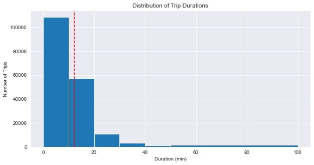

```python
plt.figure(figsize=[10, 5])
plt.hist(data = df, x = 'duration_minute',bins=[0, 10, 20, 30, 40, 50, 100])
plt.title('Distribution of Trip Durations')
plt.xlabel('Duration (min)')
plt.ylabel('Number of Trips')
plt.axvline(df['duration_minute'].mean(), color='r', linestyle='--')
plt.show()
```

## Distribution of user age

What is the relation between the age and frequency of making the rides

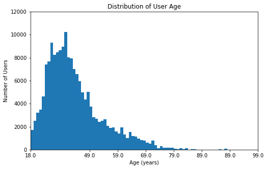

```python
binsize = 1
bins = np.arange(0, df['member_birth_year'].astype(float).max()+binsize, binsize)
minBirthYear = df['member_birth_year'].astype(float).min()
maxBirthYear =df['member_birth_year'].astype(float).max()
plt.figure(figsize=[8, 5])
plt.hist(data = df.dropna(), x = 'member_birth_year', bins = bins)
plt.axis([minBirthYear, maxBirthYear, 0, 12000])
plt.xticks([minBirthYear, minBirthYear+10, minBirthYear+20, minBirthYear+30, minBirthYear+40, minBirthYear+50, minBirthYear+60, maxBirthYear], [(2019-minBirthYear), (2019-minBirthYear-10), (2019-minBirthYear-10), (2019-minBirthYear-20), (2019-minBirthYear-30), (2019-minBirthYear-40), (2019-minBirthYear-50), (2019-maxBirthYear)])
plt.gca().invert_xaxis()
plt.title('Distribution of User Age')
plt.xlabel('Age (years)')
plt.ylabel('Number of Users')
plt.show()
```

Dropping ages with more than 100 years old to concentrate on the majority of users ages and to drop outliers.

## Bivariate relation plotting between duration and age

Trying to find the customers age with long duration rides

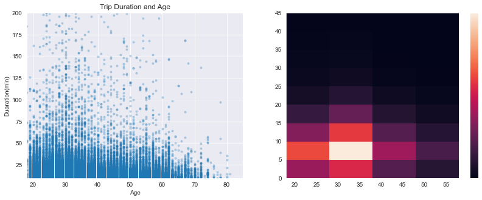

```python
plt.figure(figsize=[14,5])

plt.subplot(1, 2, 1)
plt.scatter((2019 - df['member_birth_year']), df['duration_minute'], alpha = 0.25, marker = '.' )
plt.axis([18, 85, 10, 200])
plt.title('Trip Duration and Age')
plt.xlabel('Age')
plt.ylabel('Duaration(min)')

plt.subplot(1, 2, 2)
bins_y = np.arange(0, 50, 5)
bins_x = np.arange(18, 60, 10)
plt.hist2d((2019 - df['member_birth_year']), df['duration_minute'],
           bins = [bins_x, bins_y])
plt.colorbar(ticks=[0, 10, 20, 50]);
plt.show()
```

The left plot is showing that majority of users with alot of high duration trips are with ages from 25 to 35 , the right one illustrates clearly the majority of users ages is between 20 and 40 and the max durations in mins is between 5 and 10 mins for the users with ages from 25 to 40

## Bivariate relation between duration and gender

Trying to find the gender with the highest duration

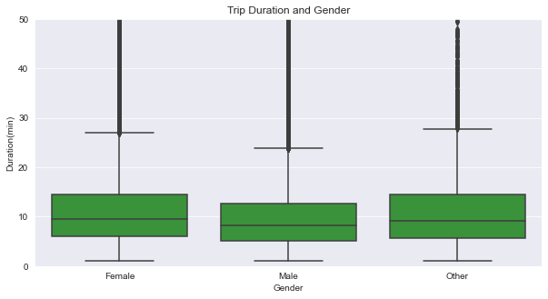

```python
plt.figure(figsize = [10, 5])
base_color = sb.color_palette()[2]
sb.boxplot(data = df, x = 'member_gender', y = 'duration_minute', color = base_color)
plt.ylim([0, 50])
plt.title('Trip Duration and Gender')
plt.xlabel('Gender')
plt.ylabel('Duration(min)')
plt.show()
```

## Distribution of member gender

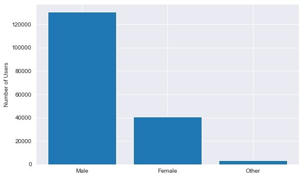

```python
plt.figure(figsize=[8,5])
plt.bar(x = df.member_gender.value_counts().keys(), height = df.member_gender.value_counts() )
plt.ylabel('Number of Users')
plt.show()
```

Female are making longer trips then males although number of male riders are very high then other and female.

## User gender and their weekly usage

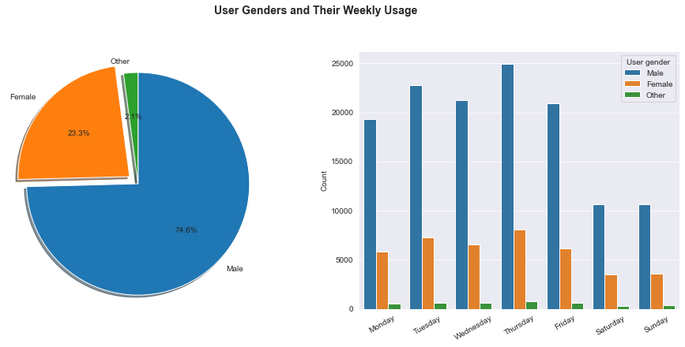

```python
plt.figure(figsize=[16, 6]);
base_color = sb.color_palette('colorblind')[3];
sb.set_style('darkgrid');

plt.subplot(1, 2, 1);
sorted_vals = df.dropna().member_gender.value_counts()/df.dropna().shape[0];
plt.pie(sorted_vals, explode=[0, 0.1, 0], labels=sorted_vals.index, startangle=90, counterclock=False, autopct='%1.1f%%', shadow=True);
plt.axis('square');

plt.subplot(1, 2, 2);
ax = sb.countplot(data=df, x='start_dayofweek', hue='member_gender', hue_order=sorted_vals.index);
ax.legend(title='User gender');
plt.xticks(rotation=30);
plt.xlabel('');
plt.ylabel('Count');
plt.suptitle('User Genders and Their Weekly Usage', fontsize=14, fontweight='semibold', y=1.015);
```

The plot is showing that the majority of trips are done during the weekdays and the most users gender is male, so we can coclude that users take rides for commuting, as the number of rides decrease in weekends.

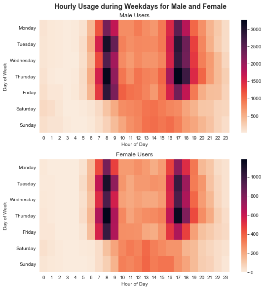

```python
plt.figure(figsize=[8, 8]);

plt.subplot(2, 1, 1)
male = df.query('member_gender == "Male"')
ct_counts = male.groupby(['start_dayofweek', 'start_hourofday']).size()
ct_counts = ct_counts.reset_index(name='count')
ct_counts = ct_counts.pivot(index='start_dayofweek', columns='start_hourofday', values='count')
sb.heatmap(ct_counts, cmap='rocket_r');
plt.title('Male Users', loc='center');
plt.xlabel('Hour of Day');
plt.ylabel('Day of Week');
plt.tight_layout();

plt.subplot(2, 1, 2)
female = df.query('member_gender == "Female"')
st_counts = female.groupby(['start_dayofweek', 'start_hourofday']).size()
st_counts = st_counts.reset_index(name='count')
st_counts = st_counts.pivot(index='start_dayofweek', columns='start_hourofday', values='count')
sb.heatmap(st_counts, cmap='rocket_r');
plt.title('Female Users', loc='center');
plt.xlabel('Hour of Day');
plt.ylabel('Day of Week');
plt.tight_layout();
plt.suptitle('Hourly Usage during Weekdays for Male and Female', fontsize=14, fontweight='semibold', y=1.015);
```

There are no different usage patterns for the two genders of riders . Many trips concentrated around 7-10am and 17-19 pm on work days when used for work commute Other than the different usage goals, it may also have to do with the traffic situation around these rush hours in the area.

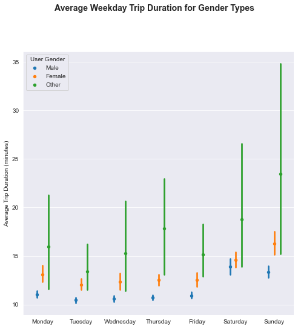

```python
plt.figure(figsize=[8, 8]);
ax = sb.pointplot(data=df, x='start_dayofweek', y='duration_minute', hue='member_gender', dodge=0.3, markers='.', linestyles="", hue_order=sorted_vals.index);
ax.legend(title='User Gender');
plt.xlabel('');
plt.ylabel('Average Trip Duration (minutes)');
plt.suptitle('Average Weekday Trip Duration for Gender Types', fontsize=14, fontweight='semibold', y=1.015);
```

The plot above shows that trip durations is the longest for the Gender type 'Others' and lowest for male.